# set-3_abundance_2cell

Caroline Spike

2025-09-08

### Code to analyze set-3 abundance in embryos with 2 nuclei

### Total abundance was quantified using Ce-bigFISH

### Code expects

set-3 smFISH data for wild-type, spn-4(tn1699), ccr-4(tm1312), ccf-1(tn2132), ccf-1(tn2168rf), CCF-1 depletion (CCF1aid), let-711(tn2130) and LET-711 depletion (LET711aid) embryos with 2 nuclei

CebigFISH settings used to generate these data:

Voxel size in nm: 250, 65, 65

set-3 spot size in nm: 300, 110, 110

chs-1 or lin-41 spot size in nm: 300, 97, 97

Embryos with >4000 set-3 spots had spot detection errors and were removed by the code.

```r
# Function to read and clean data from CSV files in subdirectories
read_data <- function(parent_directory) {

  # Function to read CSV and modify column names
  read_modify_csv <- function(file_path, subdirectory) {
    my_df <- read.csv(file_path, check.names = FALSE)  # Disable automatic name conversion
    # my_df$Image_ID <- file_path_sans_ext(basename(file_path))  # Removed to preserve actual Image ID
    my_df$subdirectory <- subdirectory

    # Remove unnecessary column if present (e.g., "X" from row indices)
    my_df <- my_df[, !colnames(my_df) %in% "X"]

    # Replace periods in column names with spaces
    colnames(my_df) <- gsub("\\.", " ", colnames(my_df))

    return(my_df)
  }

  # List all subdirectories (conditions) in the parent directory
  subdirectories <- list.dirs(parent_directory, full.names = FALSE, recursive = FALSE)

  # Initialize an empty list to store data frames
  all_data <- list()

  # Loop through subdirectories (conditions)
  for (subdirectory in subdirectories) {
    # List all CSV files in the current subdirectory
    csv_files <- list.files(path = file.path(parent_directory, subdirectory),
                            pattern = "\\.csv$", full.names = TRUE)  # Match .csv files only

    # Loop through CSV files, read data, and modify column names
    for (file_path in csv_files) {
      current_data <- read_modify_csv(file_path, subdirectory)
      all_data <- append(all_data, list(current_data))
    }
  }

  # Convert the Image_ID column to character and normalize column names
  all_data <- lapply(all_data, function(df) {
    colnames(df) <- str_replace_all(colnames(df), "[- ]", "_")  # Replace dashes and spaces with underscores
    df$Image_ID <- as.character(df$Image_ID)
    return(df)
  })

  # Combine all data frames
  combined_data <- bind_rows(all_data)

  # Filter out rows where 'set-3_mRNA_total_molecules' is 0 or > 4000, if this column exists
  if ("set_3_mRNA_total_molecules" %in% colnames(combined_data)) {
  combined_data <- combined_data %>%
    filter(set_3_mRNA_total_molecules != 0,
           set_3_mRNA_total_molecules <= 4000)
}

  # Make new informative columns
  combined_data <- combined_data %>%
    mutate(Nuclear_Stage = gsub("_.*", "", subdirectory),
           Strain = gsub("^(2_)", "", subdirectory))

  # Check the first few rows
  knitr::kable(head(combined_data))
  str(combined_data)

  # Save combined_data as a CSV file
  output_file <- file.path(parent_directory, "2cell_combined_quantification.csv")
  write.csv(combined_data, file = output_file, row.names = FALSE)
  message("Combined data saved at: ", output_file)

  return(combined_data)
}

# Usage example:
parent_directory <- "D:/Caroline/R_project_folders_set3/set3_2cell/data"
combined_data <- read_data(parent_directory)
```

```
## 'data.frame':    508 obs. of  7 variables:
##  $ Image_ID                   : chr  "70924_1024_crop.nd2" "70924_1029_crop.nd2" "70924_1040_crop.nd2" "70924_1067_crop.nd2" ...
##  $ set_3_mRNA_total_molecules : int  1259 1175 1465 1284 1334 1592 1262 1331 1487 1618 ...
##  $ chs_1_mRNA_total_molecules : int  13093 13284 12344 13177 13943 14809 11112 14686 14853 13876 ...
##  $ subdirectory               : chr  "2_CCF1aid" "2_CCF1aid" "2_CCF1aid" "2_CCF1aid" ...
##  $ lin_41_mRNA_total_molecules: int  NA NA NA NA NA NA NA NA NA NA ...
##  $ Nuclear_Stage              : chr  "2" "2" "2" "2" ...
##  $ Strain                     : chr  "CCF1aid" "CCF1aid" "CCF1aid" "CCF1aid" ...
```

```
## Combined data saved at: D:/Caroline/R_project_folders_set3/set3_2cell/data/2cell_combined_quantification.csv
```

```r
# View combined data
knitr::kable(combined_data)
```

| Image_ID | set_3_mRNA_total_molecules | chs_1_mRNA_total_molecules | subdirectory | lin_41_mRNA_total_molecules | Nuclear_Stage | Strain |
| --- | --- | --- | --- | --- | --- | --- |
| 70924_1024_crop.nd2 | 1259 | 13093 | 2_CCF1aid | NA | 2 | CCF1aid |
| 70924_1029_crop.nd2 | 1175 | 13284 | 2_CCF1aid | NA | 2 | CCF1aid |
| 70924_1040_crop.nd2 | 1465 | 12344 | 2_CCF1aid | NA | 2 | CCF1aid |
| 70924_1067_crop.nd2 | 1284 | 13177 | 2_CCF1aid | NA | 2 | CCF1aid |
| 70924_1096_crop.nd2 | 1334 | 13943 | 2_CCF1aid | NA | 2 | CCF1aid |
| 120524_11128_crop.nd2 | 1592 | 14809 | 2_CCF1aid | NA | 2 | CCF1aid |
| 120524_11132_crop.nd2 | 1262 | 11112 | 2_CCF1aid | NA | 2 | CCF1aid |
| 120524_11135_crop.nd2 | 1331 | 14686 | 2_CCF1aid | NA | 2 | CCF1aid |
| 120524_11154_crop.nd2 | 1487 | 14853 | 2_CCF1aid | NA | 2 | CCF1aid |
| 120524_11169_crop.nd2 | 1618 | 13876 | 2_CCF1aid | NA | 2 | CCF1aid |
| 120524_11180_crop.nd2 | 1405 | 12903 | 2_CCF1aid | NA | 2 | CCF1aid |
| 120524_11192_crop.nd2 | 1118 | 13051 | 2_CCF1aid | NA | 2 | CCF1aid |
| 120524_11207_crop.nd2 | 1306 | 14967 | 2_CCF1aid | NA | 2 | CCF1aid |
| 70924_1175_crop.nd2 | 1355 | 13677 | 2_CCF1aid | NA | 2 | CCF1aid |
| 70924_1258_crop.nd2 | 1383 | 13307 | 2_CCF1aid | NA | 2 | CCF1aid |
| 70924_1271_crop.nd2 | 1318 | 14799 | 2_CCF1aid | NA | 2 | CCF1aid |
| 70924_1325_crop.nd2 | 1386 | 13124 | 2_CCF1aid | NA | 2 | CCF1aid |
| 70924_1338_crop.nd2 | 1487 | 14047 | 2_CCF1aid | NA | 2 | CCF1aid |
| 70924_1354_crop.nd2 | 1296 | 13581 | 2_CCF1aid | NA | 2 | CCF1aid |
| 70924_1366_crop.nd2 | 1298 | 13801 | 2_CCF1aid | NA | 2 | CCF1aid |
| 70924_1385_crop.nd2 | 1834 | 12953 | 2_CCF1aid | NA | 2 | CCF1aid |
| 70924_1435_crop.nd2 | 1422 | 11715 | 2_CCF1aid | NA | 2 | CCF1aid |
| 70924_1457_crop.nd2 | 1406 | 12633 | 2_CCF1aid | NA | 2 | CCF1aid |
| 250610_1130_crop.nd2 | 1336 | NA | 2_CCF1aid | 14865 | 2 | CCF1aid |
| 250610_1157_crop.nd2 | 1468 | NA | 2_CCF1aid | 14422 | 2 | CCF1aid |
| 250610_1178_crop.nd2 | 1022 | NA | 2_CCF1aid | 11935 | 2 | CCF1aid |
| 250610_1207_crop.nd2 | 1025 | NA | 2_CCF1aid | 13763 | 2 | CCF1aid |
| 250610_1228_crop.nd2 | 1211 | NA | 2_CCF1aid | 13032 | 2 | CCF1aid |
| 250610_1231_crop.nd2 | 941 | NA | 2_CCF1aid | 12599 | 2 | CCF1aid |
| 250610_1244_crop.nd2 | 1246 | NA | 2_CCF1aid | 15694 | 2 | CCF1aid |

[output cut: 478 more lines]

```r
str(combined_data)
```

```
## 'data.frame':    508 obs. of  7 variables:
##  $ Image_ID                   : chr  "70924_1024_crop.nd2" "70924_1029_crop.nd2" "70924_1040_crop.nd2" "70924_1067_crop.nd2" ...
##  $ set_3_mRNA_total_molecules : int  1259 1175 1465 1284 1334 1592 1262 1331 1487 1618 ...
##  $ chs_1_mRNA_total_molecules : int  13093 13284 12344 13177 13943 14809 11112 14686 14853 13876 ...
##  $ subdirectory               : chr  "2_CCF1aid" "2_CCF1aid" "2_CCF1aid" "2_CCF1aid" ...
##  $ lin_41_mRNA_total_molecules: int  NA NA NA NA NA NA NA NA NA NA ...
##  $ Nuclear_Stage              : chr  "2" "2" "2" "2" ...
##  $ Strain                     : chr  "CCF1aid" "CCF1aid" "CCF1aid" "CCF1aid" ...
```

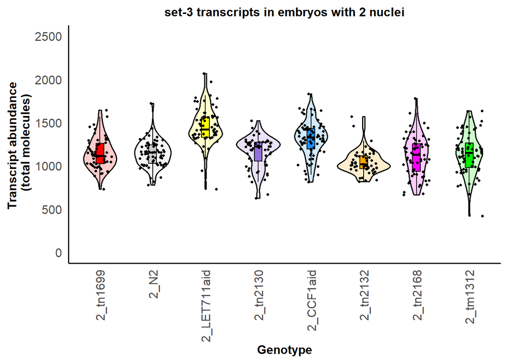

```r
# Define the custom order for subdirectories
custom_order <- c("2_tn1699", "2_N2", "2_LET711aid", "2_tn2130", "2_CCF1aid", "2_tn2132", "2_tn2168", "2_tm1312")

# Convert subdirectory to a factor with custom order
combined_data$subdirectory <- factor(combined_data$subdirectory, levels = custom_order)

# Define custom fill colors for the subdirectories
fill_colors <- c(
  "2_N2" = "gray80",
  "2_tn2132" = "orange",
  "2_CCF1aid" = "dodgerblue",
  "2_tn1699" = "red",
  "2_tm1312" = "green2",
  "2_tn2168" = "magenta",
  "2_tn2130" = "mediumpurple",
  "2_LET711aid" = "yellow"
)

# Create a combined violin and boxplot (flipped vertically)
p <- ggplot(combined_data, aes(x = factor(subdirectory, levels = custom_order), y = `set_3_mRNA_total_molecules`, fill = subdirectory)) +
  geom_violin(alpha = 0.2, color = "black", size = 0.6, width = 1.0, position = position_dodge(width = 0.8)) +
  geom_boxplot(width = 0.15, outlier.shape = NA, color = "black", notch = "false") +
  geom_jitter(height = 0, width = 0.25, color = "black", size = 0.9) +
  labs(title = "set-3 transcripts in embryos with 2 nuclei",
       x = "Genotype",
       y = "Transcript abundance \n (total molecules)") +
  scale_fill_manual(values = fill_colors) +
  theme_minimal(base_size = 14) +
  theme(axis.text.x = element_text(angle = 90, vjust = 0.5, hjust=1),  # Rotate labels on x-axis
        legend.position = "none",  # Remove legend
        panel.grid.major = element_blank(),
        panel.grid.minor = element_blank(),
        panel.border = element_blank(),
        axis.line = element_line(color = "black"),
        plot.title = element_text(hjust = 0.5, size = 12, face = "bold"),
        axis.title = element_text(size = 12, face = "bold"),
        axis.text = element_text(size = 12),
        axis.ticks = element_blank()) +
  coord_cartesian(ylim = c(0, 2500))

# Display the plot
print(p)
```

```r
# Save the plot as SVG with the date in the filename
ggsave(paste0("D:/Caroline/R_project_folders_set3/set3_2cell/output/",
              date_today, "_set-3-mRNA-abundance-violin-plot.svg"),
       p, width = 10, height = 8)

# Save the plot as PDF with the date in the filename
ggsave(paste0("D:/Caroline/R_project_folders_set3/set3_2cell/output/",
              date_today, "_set-3-mRNA-abundance-violin-plot.pdf"),
       p, width = 10, height = 8)
```

Statistical analysis

Shapiro-Wilk: Test for normal distribution.

Levene: Test for equal variance.

Welch’s test: Parametric test for differences among groups. Does not assume equal variance.

Games-Howell test: A post-hoc test for Welch’s ttest.

Kruskal-Wallis: Non-parametric test for differences among groups.

Dunn test: A post-hoc test for Kruskal-Wallis. Used Benjamini-Hochberg correction for multiple testing.

Conover-Iman test: A more sensitive post-hoc test for Kruskal-Wallis. A more conservative Benjamini-Yekutieli correction for multiple testing.

```r
# Test significant differences in set-3 mRNA abundance between each "subdirectory" ( dev. stage + strain)
# Shapiro-Wilk test for normal distributions
shapiro_result <- shapiro.test(combined_data$set_3_mRNA_total_molecules)
by(combined_data$set_3_mRNA_total_molecules, combined_data$subdirectory, shapiro.test)
```

```
## combined_data$subdirectory: 2_tn1699
##
##  Shapiro-Wilk normality test
##
## data:  dd[x, ]
## W = 0.97263, p-value = 0.241
##
## --------------------------------------------------------------------------------------------------------------------------
## combined_data$subdirectory: 2_N2
##
##  Shapiro-Wilk normality test
##
## data:  dd[x, ]
## W = 0.96035, p-value = 0.03155
##
## --------------------------------------------------------------------------------------------------------------------------
## combined_data$subdirectory: 2_LET711aid
##
##  Shapiro-Wilk normality test
##
## data:  dd[x, ]
## W = 0.95663, p-value = 0.02456
##
## --------------------------------------------------------------------------------------------------------------------------
## combined_data$subdirectory: 2_tn2130
##
##  Shapiro-Wilk normality test
##
## data:  dd[x, ]
## W = 0.91487, p-value = 0.0005378
##
## --------------------------------------------------------------------------------------------------------------------------
## combined_data$subdirectory: 2_CCF1aid
##
##  Shapiro-Wilk normality test
##
## data:  dd[x, ]
## W = 0.9802, p-value = 0.258
##
## --------------------------------------------------------------------------------------------------------------------------
## combined_data$subdirectory: 2_tn2132
##
##  Shapiro-Wilk normality test
##
## data:  dd[x, ]
## W = 0.90174, p-value = 0.0003705
##
## --------------------------------------------------------------------------------------------------------------------------
## combined_data$subdirectory: 2_tn2168
##
##  Shapiro-Wilk normality test
##
## data:  dd[x, ]
## W = 0.98498, p-value = 0.6281
##
## --------------------------------------------------------------------------------------------------------------------------
## combined_data$subdirectory: 2_tm1312
##
##  Shapiro-Wilk normality test
##
## data:  dd[x, ]
## W = 0.98303, p-value = 0.4931
```

```r
# Test homogeneity of variance using Levene's Test.
leveneTest(set_3_mRNA_total_molecules ~ subdirectory, data = combined_data)
```

```
## Levene's Test for Homogeneity of Variance (center = median)
##        Df F value   Pr(>F)
## group   7  3.3898 0.001512 **
##       500
## ---
## Signif. codes:  0 '***' 0.001 '**' 0.01 '*' 0.05 '.' 0.1 ' ' 1
```

```r
# Welch's ANOVA: a parametric test that does not assume equal variance
oneway.test(set_3_mRNA_total_molecules ~ subdirectory, data = combined_data)
```

```
##
##  One-way analysis of means (not assuming equal variances)
##
## data:  set_3_mRNA_total_molecules and subdirectory
## F = 27.685, num df = 7.00, denom df = 211.26, p-value < 2.2e-16
```

```r
# Games Howell: a post-hoc test for Welch's ANOVA
# Games-Howell test
games_results <- combined_data %>%
  games_howell_test(set_3_mRNA_total_molecules ~ subdirectory)

# Display Games-Howell post hoc test results
games_results_df <- as.data.frame(games_results)
games_results_df %>%
  dplyr::select(group1, group2, estimate, p.adj, p.adj.signif) %>%
  print()
```

```
##         group1      group2     estimate    p.adj p.adj.signif
## 1     2_tn1699        2_N2   -1.2363636 1.00e+00           ns
## 2     2_tn1699 2_LET711aid  313.4511364 1.18e-12         ****
## 3     2_tn1699    2_tn2130   17.8992296 9.99e-01           ns
## 4     2_tn1699   2_CCF1aid  167.1686997 4.44e-05         ****
## 5     2_tn1699    2_tn2132  -97.2740995 4.10e-02            *
## 6     2_tn1699    2_tn2168  -29.6582386 9.94e-01           ns
## 7     2_tn1699    2_tm1312   -1.3856174 1.00e+00           ns
## 8         2_N2 2_LET711aid  314.6875000 1.29e-13         ****
## 9         2_N2    2_tn2130   19.1355932 9.98e-01           ns
## 10        2_N2   2_CCF1aid  168.4050633 1.80e-06         ****
## 11        2_N2    2_tn2132  -96.0377358 1.10e-02            *
## 12        2_N2    2_tn2168  -28.4218750 9.92e-01           ns
## 13        2_N2    2_tm1312   -0.1492537 1.00e+00           ns
## 14 2_LET711aid    2_tn2130 -295.5519068 1.07e-11         ****
## 15 2_LET711aid   2_CCF1aid -146.2824367 2.00e-03           **
## 16 2_LET711aid    2_tn2132 -410.7252358 1.65e-14         ****
## 17 2_LET711aid    2_tn2168 -343.1093750 9.67e-13         ****
## 18 2_LET711aid    2_tm1312 -314.8367537 2.65e-11         ****
## 19    2_tn2130   2_CCF1aid  149.2694701 3.58e-04          ***
## 20    2_tn2130    2_tn2132 -115.1733291 6.00e-03           **
## 21    2_tn2130    2_tn2168  -47.5574682 9.10e-01           ns
## 22    2_tn2130    2_tm1312  -19.2848470 1.00e+00           ns
## 23   2_CCF1aid    2_tn2132 -264.4427991 1.85e-13         ****
## 24   2_CCF1aid    2_tn2168 -196.8269383 1.32e-05         ****
## 25   2_CCF1aid    2_tm1312 -168.5543170 2.87e-04          ***
## 26    2_tn2132    2_tn2168   67.6158608 5.28e-01           ns
## 27    2_tn2132    2_tm1312   95.8884821 1.14e-01           ns
## 28    2_tn2168    2_tm1312   28.2726213 9.97e-01           ns
```

```r
# Kruskal-Wallis non-parametric test may be more appropriate. The distributions of four subgroups deviate significantly from normality.
kruskal.test(set_3_mRNA_total_molecules ~ subdirectory, data = combined_data)
```

```
##
##  Kruskal-Wallis rank sum test
##
## data:  set_3_mRNA_total_molecules by subdirectory
## Kruskal-Wallis chi-squared = 147.71, df = 7, p-value < 2.2e-16
```

```r
# Use the Dunn test with Benjamini-Hochberg correction to determine significance between groups.
dunn_results <- combined_data %>%
  dunn_test(set_3_mRNA_total_molecules ~ subdirectory, p.adjust.method = "BH")

# Summarize the results of the Dunn test.
dunn_results %>%
  dplyr::mutate(
    p.adj = signif(p.adj, 3)
  ) %>%
  dplyr::select(group1, group2, p.adj, p.adj.signif) %>%
  dplyr::arrange(p.adj) %>%
  print(n = Inf)
```

```
## # A tibble: 28 × 4
##    group1      group2         p.adj p.adj.signif
##    <chr>       <chr>          <dbl> <chr>
##  1 2_LET711aid 2_tn2132    1.03e-21 ****
##  2 2_LET711aid 2_tn2168    2.38e-14 ****
##  3 2_N2        2_LET711aid 2.48e-13 ****
##  4 2_CCF1aid   2_tn2132    8.29e-13 ****
##  5 2_LET711aid 2_tm1312    1.10e-12 ****
##  6 2_tn1699    2_LET711aid 1.54e-12 ****
##  7 2_LET711aid 2_tn2130    5.40e-10 ****
##  8 2_CCF1aid   2_tn2168    5.19e- 7 ****
##  9 2_N2        2_CCF1aid   3.65e- 6 ****
## 10 2_tn1699    2_CCF1aid   9.69e- 6 ****
## 11 2_CCF1aid   2_tm1312    1.17e- 5 ****
## 12 2_tn2130    2_CCF1aid   5.2 e- 4 ***
```

[output cut: 16 more lines]

```r
# Save Dunn's output as a csv
dunn_summary <- dunn_results %>%
  dplyr::mutate(
    p.adj = signif(p.adj, 3)
  ) %>%
  dplyr::select(group1, group2, p.adj, p.adj.signif) %>%
  dplyr::arrange(p.adj)

write.csv(dunn_summary,
          file = paste0("D:/Caroline/R_project_folders_set3/set3_2cell/output/", date_today, "_dunn_results.csv"),
          row.names = FALSE)

# Run Conover-Iman test with Benjamini-Yekutieli correction to determine significance between groups.
conover_result <- kwAllPairsConoverTest(set_3_mRNA_total_molecules ~ subdirectory,
                                data = combined_data,
                                p.adjust.method = "BY")

# Display Conover-Iman post hoc test results
print(conover_result)
```

```
##
##  Pairwise comparisons using Conover's all-pairs test
```

```
## data: set_3_mRNA_total_molecules by subdirectory
```

```
##             2_tn1699 2_N2    2_LET711aid 2_tn2130 2_CCF1aid 2_tn2132 2_tn2168
## 2_N2        1.00000  -       -           -        -         -        -
## 2_LET711aid 2.0e-15  < 2e-16 -           -        -         -        -
## 2_tn2130    1.00000  1.00000 2.7e-12     -        -         -        -
## 2_CCF1aid   7.6e-07  2.1e-07 0.00208     0.00015  -         -        -
## 2_tn2132    0.01425  0.00782 < 2e-16     0.00021  8.9e-16   -        -
## 2_tn2168    1.00000  1.00000 < 2e-16     0.60776  1.6e-08   0.03732  -
## 2_tm1312    1.00000  1.00000 1.3e-15     1.00000  1.0e-06   0.00288  1.00000
```

```
##
## P value adjustment method: BY
```

```r
# Extract and convert Conover-Iman results to a data frame
conover_summary <- as.data.frame(conover_result$p.value)

# Save to CSV
write.csv(conover_summary,
          file = paste0("D:/Caroline/R_project_folders_set3/set3_2cell/output/",
                        date_today, "_conover_results.csv"),
          row.names = TRUE)

# Summarize important metrics that describe the underlying data.
combined_data %>%
  group_by(subdirectory) %>%
  summarize(mean = mean(set_3_mRNA_total_molecules),
            median = median(set_3_mRNA_total_molecules),
            sd = sd(set_3_mRNA_total_molecules),
            n = n())
```

```
## # A tibble: 8 × 5
##   subdirectory  mean median    sd     n
##   <fct>        <dbl>  <dbl> <dbl> <int>
## 1 2_tn1699     1144.   1117  178.    55
## 2 2_N2         1143    1154  152.    67
## 3 2_LET711aid  1458.   1423  219.    64
## 4 2_tn2130     1162.   1225  183.    59
## 5 2_CCF1aid    1311.   1331  204.    79
## 6 2_tn2132     1047.   1019  139.    53
## 7 2_tn2168     1115.   1130  233.    64
## 8 2_tm1312     1143.   1150  236.    67
```